# Tarea 3

Grupo 2

2025-09-03

En una planta química hay dos máquinas que envasan detergentes industriales en bidones con un volumen de producto que sigue una distribución normal con desviación estándar de 1 litro. La ingeniera a cargo de la planta debe asegurar que los bidones se están llenando con una media de 10 litros. Pero ella tiene la sospecha de que hay desviaciones en esta media, lo que piensa confirmar usando una muestra aleatoria de 100 envases (50 de cada una de las máquinas). También cree que hay diferencia en el cumplimiento del volumen requerido entre la máquina más antigua y la más moderna, que han de andar por el 90% y 96% de los bidones, respectivamente.

1. Si la ingeniera está seguro de que el verdadero volumen medio no puede ser inferior a 10 litros y piensa rechazar la hipótesis nula cuando la muestra presente una media mayor a 10,25 litros, ¿cuál es la probabilidad de que cometa un error de tipo I? Para responder, generen un gráfico de la distribución muestral de las medias hipotetizada en donde se marque la zona correspondiente a la probabilidad solicitada, para luego, basándose en este gráfico, calcular el área correspondiente. Tome como ejemplo los scripts presentados en la lectura sobre poder estadístico.

Planteamiento de hipotesis, según el contexto:

H0: El volumen medio de producto que contienen los bidones es igual a 10 litros.
$$H_0: \mu = 10$$
Ha: El volumen medio de producto que contienen los bidones es mayor a 10 litros.
$$H_a: \mu > 10$$

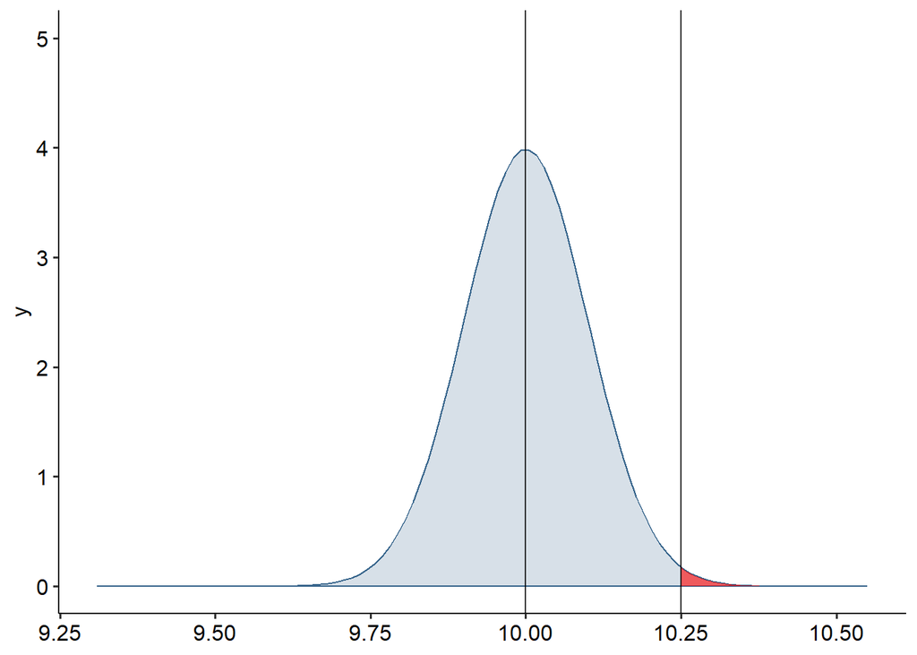

```r
#Datos en base al enunciado
media <- 10 #Media nula
sd <- 1 #Desviación estándar
n <- 100 #Tamaño de la muestra

media_critica <- 10.25 #Valor máximo de la media
SE <- sd/sqrt(n) #Error estándar

#Construcción del gráfico
g_x_limites <- media + c(-6.9, 5.5) * SE
g <- ggplot() + xlim(g_x_limites) + ylim(0, 5) +
  theme_pubr()

#Distribución muestral bajo H0
dist_0 <- stat_function(fun = dnorm, geom = "area",
                        args = list(mean = media, sd = SE),
                        colour = "steelblue4", fill = "steelblue4",
                        alpha = 0.2)

g1 <- g + dist_0
g1 <- g1 + geom_vline(xintercept = media, fill = "steelblue4", alpha = 0.8)
#Coloreo de la región de rechazo
g2_aux <- g1 + stat_function(fun = dnorm, geom = "area",
                         args = list(mean = media, sd = SE),
                         xlim = c(10.25, g_x_limites[2]),
                         fill = "red", alpha = 0.6)

# Mostrar el gráfico
print (g2_aux + geom_vline(xintercept = media_critica, fill = "red", alpha = 0.8))
```

```r
#Z crítico
z <- (media_critica - media)/SE

#Calculo de Error tipo I
error <- pnorm(z, mean = 0, sd = 1, lower.tail = FALSE)
print(error)
```

```
## [1] 0.006209665
```

La probabilidad de cometer un error de tipo I es aproximadamente 0.0062 (0.62%). Esto significa que hay un 0.62% de probabilidad de rechazar la hipótesis nula (decir que la media es mayor que 10) cuando en realidad es verdadera, osea que la media es realmente igual a 10 litros.

2. Si el verdadero volumen medio de los bidones fuera de 10,2 litros, ¿cuál sería la probabilidad de que la ingeniera, que obviamente no conoce este dato, cometa un error de tipo II? Para responder, agregue al gráfico anterior la verdadera distribución muestral de las medias y marquen (con otro color) la zona correspondiente a la probabilidad solicitada, para luego, basándose en este gráfico, calcular el área correspondiente. También hay ejemplos de este procedimiento en la lectura sobre poder estadístico.

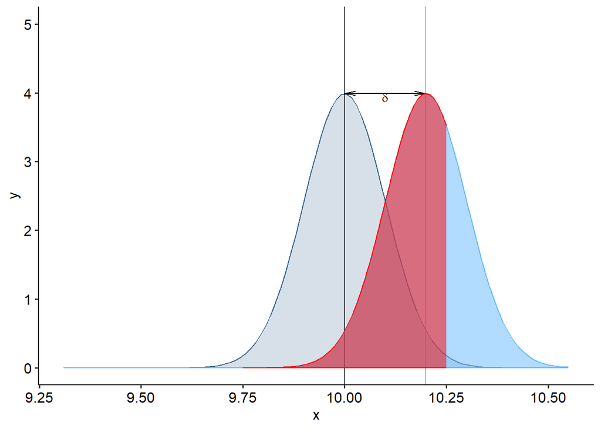

```r
#Media verdadera (Del enunciado)
media_verdadera <- 10.2
#Valor de alfa (De la pregunta anterior)
alfa <- 0.006209665

#Agregar la verdadera distribución muestral de las medias
g3 <- g1 + stat_function(fun = dnorm, geom = "area",
                         args = list(mean = media_verdadera,
                                     sd = SE),
                         colour = "steelblue1",
                         fill = "steelblue1", alpha = 0.5)

#Marca de la media verdadera en el gráfico
g3 <- g3 + geom_vline(xintercept = media_verdadera,
                      colour = "steelblue1")

# Agregar anotación del tamaño del efecto y mostrar el gráfico que resulta
x_ann <- c(media_verdadera, media)
y_ann <- c(dnorm(media_verdadera, mean = media_verdadera,
                 sd = SE),
           dnorm(media, mean = media, sd= SE))
y_ann <- y_ann + 0.005


g4 <- g3 + annotate("segment", x = x_ann[1], y = y_ann[1],
                    xend = x_ann[2], yend = y_ann[2],
                    arrow = arrow(angle = 10,
                                  length = unit (0.03, "npc"),
                                  ends = "both", type = "open"))

g4 <- g4 + annotate("text", x = sum(x_ann)/2,
                    y = y_ann[1] + 0.015,
                    label = "delta", vjust = "top",
                    parse = TRUE)

#Calcular y colorear las regiones críticas de la hipótesis nula
z_critico_inferior <- qnorm (alfa, mean = media, sd = SE, lower.tail = TRUE)
z_critico_superior <- qnorm (alfa, mean = media, sd = SE, lower.tail = FALSE)

#Marcar y colorear el area de la región β
g5 <- g4 + stat_function(fun = dnorm, geom = "area",
                         args = list(mean = media_verdadera, sd = SE),
                         xlim = c(z_critico_inferior, z_critico_superior),
                         fill = "red",
                         colour = "red",
                         alpha = 0.5)

print(g5)
```

El gráfico anterior muestra la región del poder superior, de color celeste y la región β, de color rojo. Cabe señalar que el valor del poder inferior es tan bajo que no se puede visualizar en el gráfico

```r
#Cálculo del poder
poder_inf <- pnorm(z_critico_inferior,
                   mean = media_verdadera,
                   sd = SE,
                   lower.tail = TRUE)

poder_sup <- pnorm(z_critico_superior,
                   mean = media_verdadera,
                   sd = SE,
                   lower.tail = FALSE)

#Cálculo del valor β
cat("Valor beta: ", 1 - poder_sup + poder_inf)
```

```
## Valor beta:  0.6914659
```

Con un β = 0.6914659 (aproximadamente 69.14%).

Esto significa que si la media verdadera es 10.2 litros, hay un 69.14% de probabilidad de que la ingeniera no rechace H0 (decir que la media es 10 litros) cuando en realidad la media es 10.2 litros (cometiendo así un error tipo II).

3. Como no se conoce el verdadero volumen medio, genere un gráfico del poder estadístico con las condiciones anteriores, pero suponiendo que el verdadero volumen medio podría variar de 10 a 10,5 litros. Hay un ejemplo de este tipo de gráfico en la lectura sobre poder estadístico.

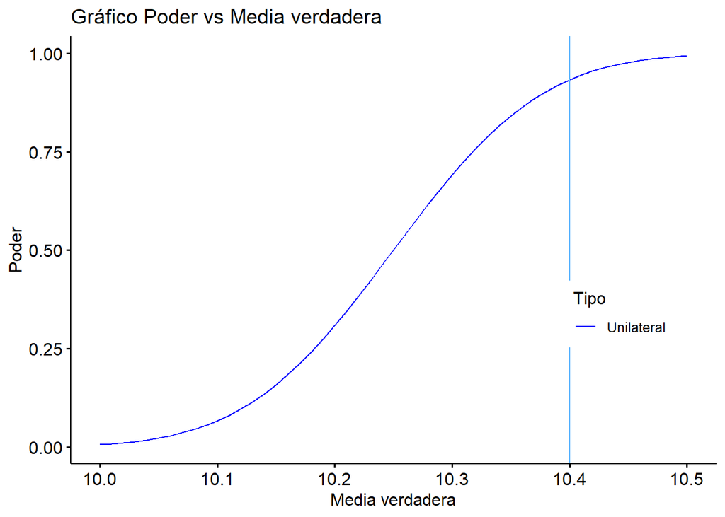

```r
media_nula <- 10 #Media nula

medias_verdaderas <- seq(10, 10.5, 0.01)
deltas <- medias_verdaderas - media_nula
deltas_normalizados <- deltas / sd

f_pzl <- function(x) pwr.norm.test(x, n = n,
                                   sig.level = alfa,
                                   alternative = "greater")[["power"]]

poder_unilat <- sapply(deltas_normalizados, f_pzl)

# Usamos medias_verdaderas en lugar de deltas
datos_anchos <- data.frame(medias_verdaderas, poder_unilat)
datos_largos <- datos_anchos |>
  pivot_longer(-medias_verdaderas, names_to = "Tipo", values_to = "Poder")
datos_largos[["Tipo"]] <- factor(datos_largos[["Tipo"]],
                                 labels = c("Unilateral"))

grafico <- ggline(datos_largos, x = "medias_verdaderas", y = "Poder",
                  plot_type = "l", numeric.x.axis = TRUE,
                  title = "Gráfico Poder vs Media verdadera",
                  xlab = "Media verdadera",
                  color = "Tipo",
                  palette = c("blue"))
grafico <- ggpar(grafico, legend = c(.85, .35))

grafico <- grafico + geom_vline(xintercept = 10.4,
                      colour = "steelblue1")

print(grafico)
```

Al analizar el gráfico notamos que, si la media tiene un valor de 10.4, el poder resultante es cercano a 1. Ahora se usará una prueba “pwr.norm.test” para verificar el valor real del poder y decidir si se puede usar esta media para proximos cálculos. Utilizando un tamaño de efecto normalizado de 0.4, resultante de la resta entre 10.4 y la media nula, dividido por la desviación estándar.

```r
poder_aux <- pwr.norm.test(0.4,
                     n = n,
                     sig.level = alfa,
                     alternative = "greater")

print(poder_aux)
```

```
##
##      Mean power calculation for normal distribution with known variance
##
##               d = 0.4
##               n = 100
##       sig.level = 0.006209665
##           power = 0.9331928
##     alternative = greater
```

El valor del poder que retorna la prueba es de 0.93 aproximadamente, lo que indica que 10.4 es una media aceptable para calcular el tamaño del efecto

4. Considerando un volumen medio de 10 litros, ¿cuántos bidones deberían revisarse para conseguir un poder estadístico de 0,75 y un nivel de significación de 0,05?

H0: El volumen medio de producto que contienen los bidones es igual a 10 litros.
$$H_0: \mu = 10$$
Ha: El volumen medio de producto que contienen los bidones es mayor a 10 litros.
$$H_a: \mu > 10$$

```r
#Datos del enunciado
vol_medio <- 10
poder <- 0.75
alpha <- 0.05

d <- 0.4 #Tamaño del efecto normalizado

pwr.norm.test(n = NULL, d = d, power = poder, sig.level = alpha, alternative = "greater")
```

```
##
##      Mean power calculation for normal distribution with known variance
##
##               d = 0.4
##               n = 33.62098
##       sig.level = 0.05
##           power = 0.75
##     alternative = greater
```

En base a la prueba realizada anteriormente, se necesitan aproximadamente 34 bidones para conseguir un poder estadístico de 0,75 y un nivel de significación de 0,05

5. ¿Alcanzaría esta muestra para detectar la diferencia que la ingeniera sospecha que existe entre las dos máquinas de la planta con al menos las mismas probabilidades de cometer errores?

En base al contexto y la pregunta, se plantean las siguientes hipotesis.

H0: La proporción de cumplimiento de la maquina nueva y la antigua es la misma
$$H_0: p_{\text{antigua}} =
p_{\text{nueva}}$$
Ha: Existe una diferencia entre las proporciones de cumplimiento de la máquina antigual y la nueva.
$$H_a: p_{\text{antigua}} \neq
p_{\text{nueva}}$$

```r
h <- ES.h(0.9, 0.96) #h de Cohen

#Potencia de la prueba de la diferencia de dos proporciones, con muestra de igual tamaño
#(Se toma el poder y nivel de significancia de la pregunta anterior)
pwr.2p.test(h = h, n = NULL, sig.level = 0.05, power = 0.75, alternative = "two.sided")
```

```
##
##      Difference of proportion power calculation for binomial distribution (arcsine transformation)
##
##               h = 0.2407853
##               n = 239.4137
##       sig.level = 0.05
##           power = 0.75
##     alternative = two.sided
##
## NOTE: same sample sizes
```

En base a la prueba de potencia anterior, notamos que se necesita una muestra de 240 bidones para detectar la diferencia que la ingeniera sospecha que existe entre las dos máquinas de la planta, sin embargo, la pregunta de la pregunta anterior se obtuvo una muestra de tamaño 34, lo que resulta insuficiente para comprobar las sospechas de la ingeniera.